# Coding Club - Introduction to R - Part II

# Synopsis

In this tutorial we will first understand R Markdown and then study how to explore data using the *tidyverse* package. These are based on the book R for Data Science.

### R Markdown

*{Getting started - hands on demo}*

1. R Markdown is unified framework for communicating data science.
2. Reproducible and supports several formats
3. R Markdown files are designed to be used in three ways:

   3a. For communicating to decision makers, who want to focus on the conclusions, not the code behind the analysis.

   3b. For collaborating with other data scientists on how you reached the conclusions and the code.

   3c. To act as a lab notebook to jot down not just the results but what you were thinking.
4. Help may not be available through ?, as it integrates lots of external packages. These resources may be useful

   4a. R Markdown Cheat Sheet: Help > Cheatsheets > R Markdown Cheat Sheet,

   4b. R Markdown Reference Guide: Help > Cheatsheets > R Markdown Reference Guide.
5. Both cheatsheets are also available at http://rstudio.com/cheatsheets.

### Explore

Download the data set *inputevents_cv.csv* from Github

```r
# Load the library and get the data. If you don't have this package you need to install it
library(RCurl)
my_URL <- "https://raw.githubusercontent.com/kannan-kasthuri/Coding.Club/master/inputevents_cv.csv"
my_data <- read.csv(text=getURL(my_URL), header=T)
```

You need the *tidyverse* package. Go ahead install the package in the console

`> install.packages("tidyverse")`

We can now go ahead and look at the data frame.

```r
# Display the data frame
my_data[1:5, 1:5]
```

```
##   X row_id subject_id hadm_id icustay_id
## 1 1   9805      15017  158961     281789
## 2 2   9806      15017  158961     281789
## 3 3   9807      15017  158961     281789
## 4 4   9808      15017  158961     281789
## 5 5  10512      12113  162590     204849
```

Now lets look at the column names of the data frame.

```r
# Look into the columns of the data frame and identify their types
# Note: one can equally use the 'str' function
sapply(my_data,class)
```

```
##                 X            row_id        subject_id           hadm_id
##         "integer"         "integer"         "integer"         "integer"
##        icustay_id         charttime            itemid            amount
##         "integer"          "factor"         "integer"         "numeric"
##         amountuom              rate           rateuom         storetime
##          "factor"         "numeric"          "factor"          "factor"
##              cgid           orderid       linkorderid           stopped
##         "integer"         "integer"         "integer"          "factor"
##         newbottle    originalamount originalamountuom     originalroute
##         "integer"         "numeric"          "factor"          "factor"
##      originalrate   originalrateuom      originalsite
##         "numeric"          "factor"          "factor"
```

Lets create a ggplot now

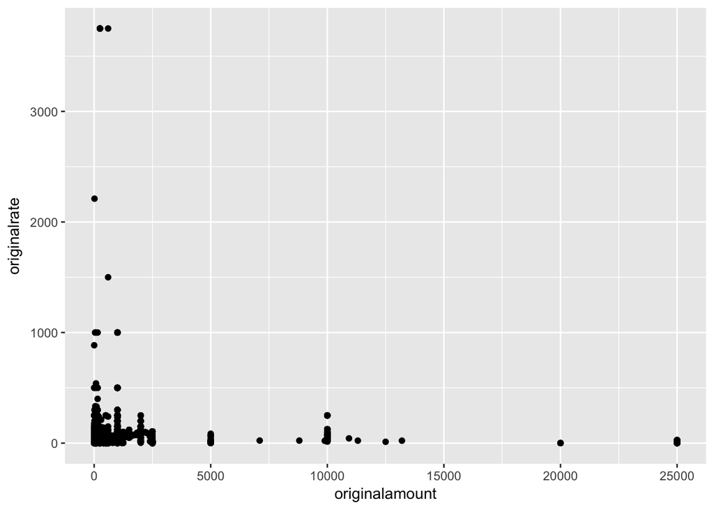

```r
# Load the tidyverse library and create a scatter plot of originalamount and originalrate
library(tidyverse)
ggplot(data = my_data) + geom_point(mapping = aes(x = originalamount, y = originalrate))
```

The limits are too off. Set the limits

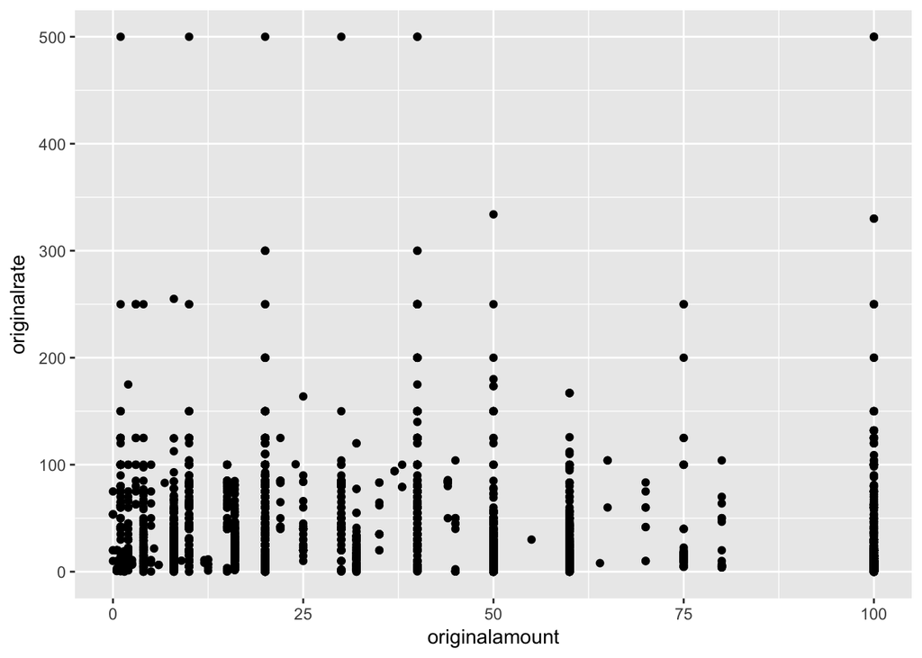

```r
# Set the proper limits to identify regions of interest and to exclude outliers
ggplot(data = my_data) +
  geom_point(mapping = aes(x = originalamount, y = originalrate)) +
  xlim(0,100) + ylim(0,500)
```

General graphing template:

`ggplot(data = <DATA>) + <GEOM_FUNCTION>(mapping = aes(<MAPPINGS>))`

#### Aesthetic mappings

We can introduce the asthetic color to map the attribute *originalroute* to the points

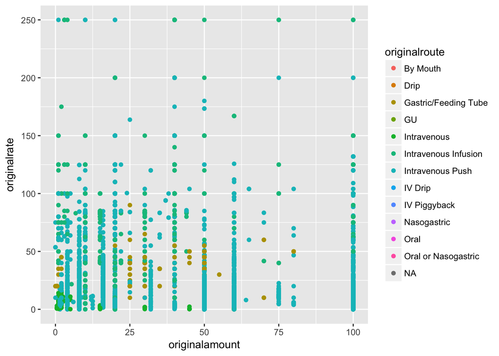

```r
# Color the labels of the originalroute class
ggplot(data = my_data) +
  geom_point(mapping = aes(x = originalamount, y = originalrate, color = originalroute)) +
  xlim(0,100) + ylim(0,250)
```

Or we could have mapped *originalroute* to the alpha aesthetic, which controls the transparancy of the points

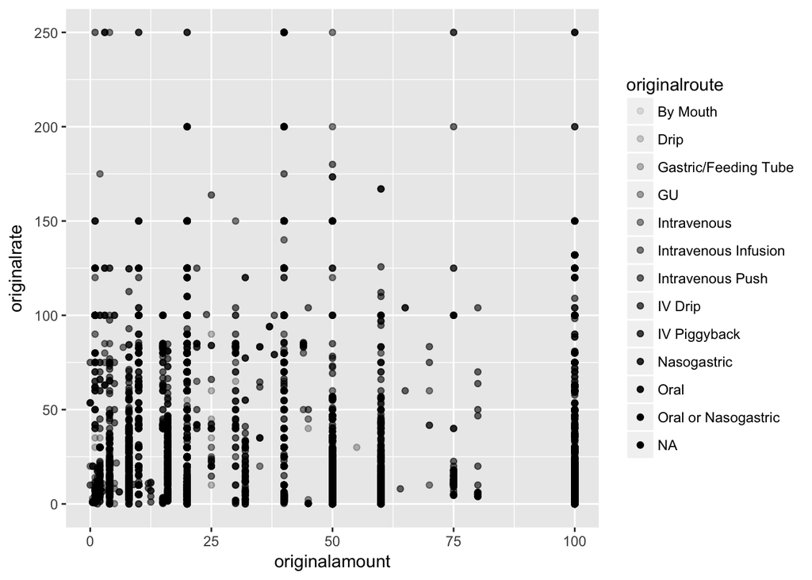

```r
# Set transparancy using 'alpha'
ggplot(data = my_data) +
  geom_point(mapping = aes(x = originalamount, y = originalrate, alpha = originalroute)) +
  xlim(0,100) + ylim(0,250)
```

or to the shape of the points (**Note** ggplot2 will only use six shapes at a time).

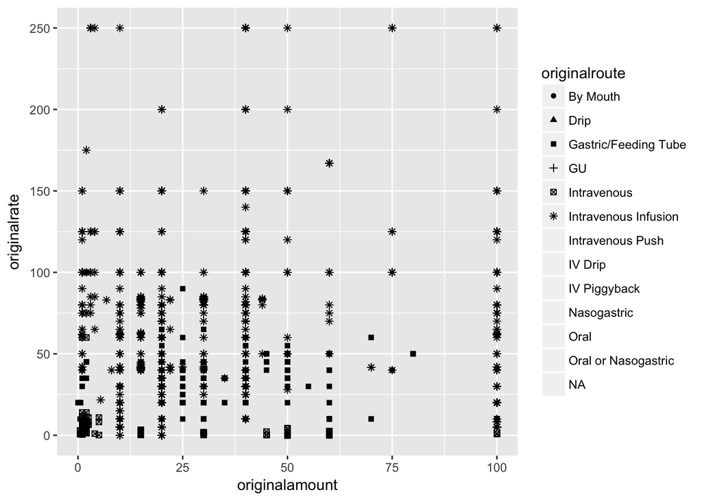

```r
# Set the shape instead of transparancy/color
ggplot(data = my_data) +
  geom_point(mapping = aes(x = originalamount, y = originalrate, shape = originalroute)) +
  xlim(0,100) + ylim(0,250)
```

Or you can specify your own color (*note*: the changed x-axis limits)

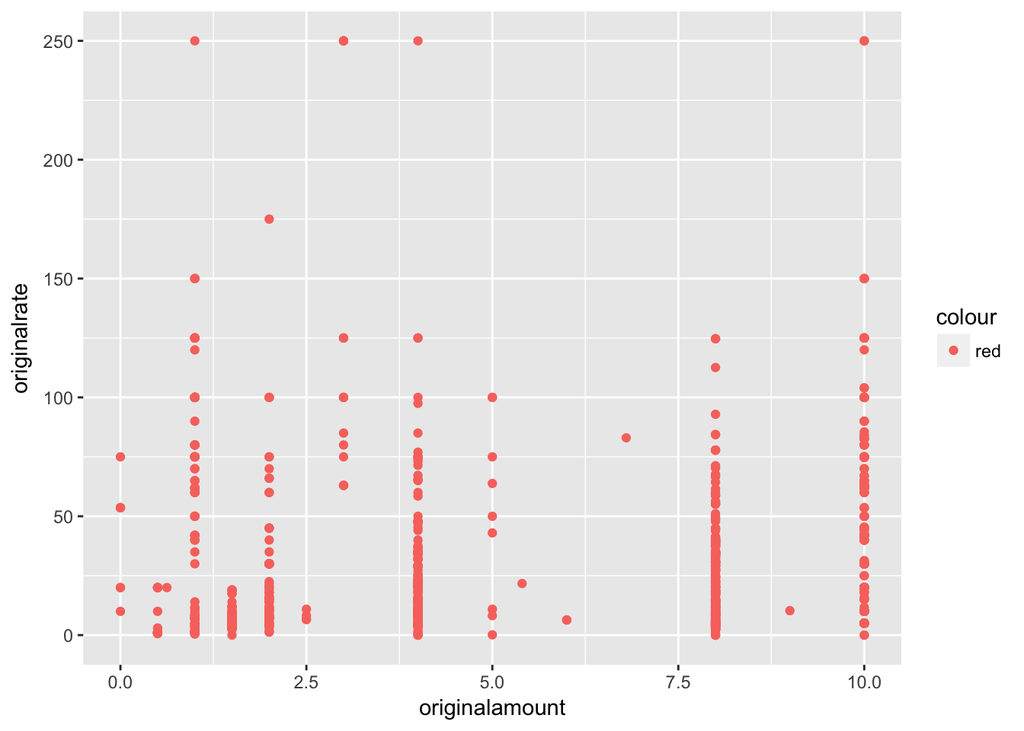

```r
# Or specify your own color
ggplot(data = my_data) +
  geom_point(mapping = aes(x = originalamount, y = originalrate, color = "red")) +
  xlim(0,10) + ylim(0,250)
```

So far none of the plots are helpful in distingushing the number of points found in each class. Another way, particularly useful for categorical variables, is to split your plot into facets, subplots that each display one subset of the data using `facet_wrap()`

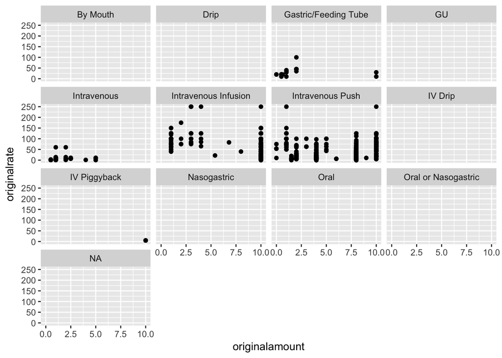

```r
# Use 'facet_wrap()' to create facets
ggplot(data = my_data) +
  geom_point(mapping = aes(x = originalamount, y = originalrate)) +
  xlim(0,10) + ylim(0,250) +
  facet_wrap(~ originalroute, nrow = 4)
```

In fact, you can add colors to the facets,

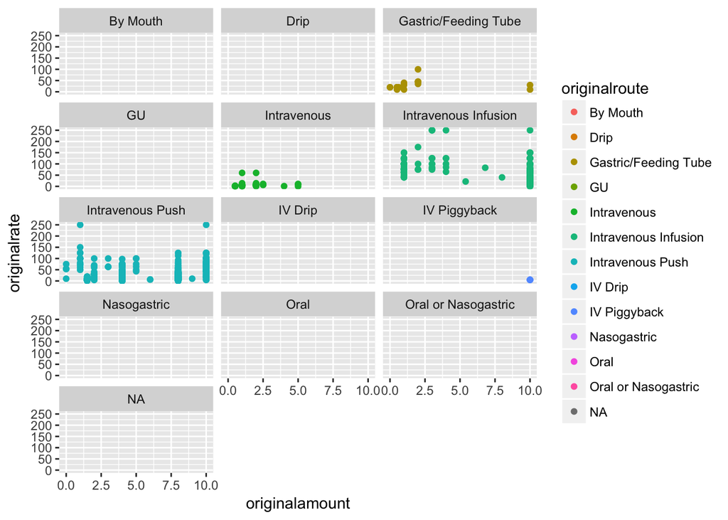

```r
# We can include colors in 'facet_wrap'
ggplot(data = my_data) +
  geom_point(mapping = aes(x = originalamount, y = originalrate, color = originalroute)) +
  xlim(0,10) + ylim(0,250) +
  facet_wrap(~ originalroute, nrow = 5)
```

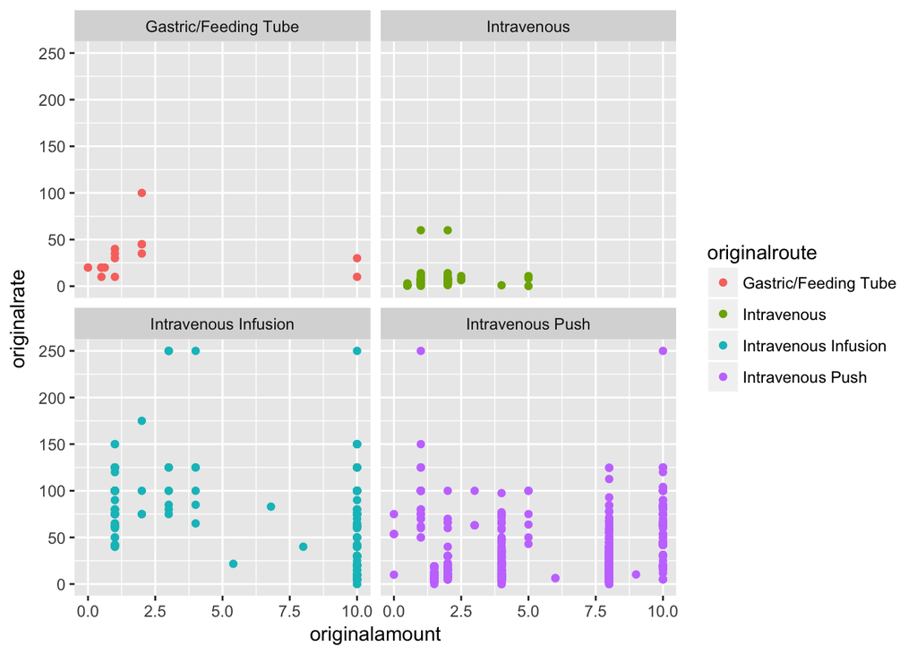

```r
# First filter the data for the labels that contain the data
my_filtered_results <- filter(my_data, originalroute == "Gastric/Feeding Tube" |
                                originalroute == "Intravenous" | originalroute == "Intravenous Infusion" |
                                originalroute == "Intravenous Push")

# Plot the filtered data
ggplot(data = my_filtered_results) +
  geom_point(mapping = aes(x = originalamount, y = originalrate, color = originalroute)) +
  xlim(0,10) + ylim(0,250) + facet_wrap(~ originalroute, nrow = 2)
```

To facet our plot on the combination of two variables, add we add `facet_grid()` to the plot. The first argument of `facet_grid()` is also a formula. This time the formula should contain two variable names separated by a ~. We use the attribute *stopped* as one of the variables.

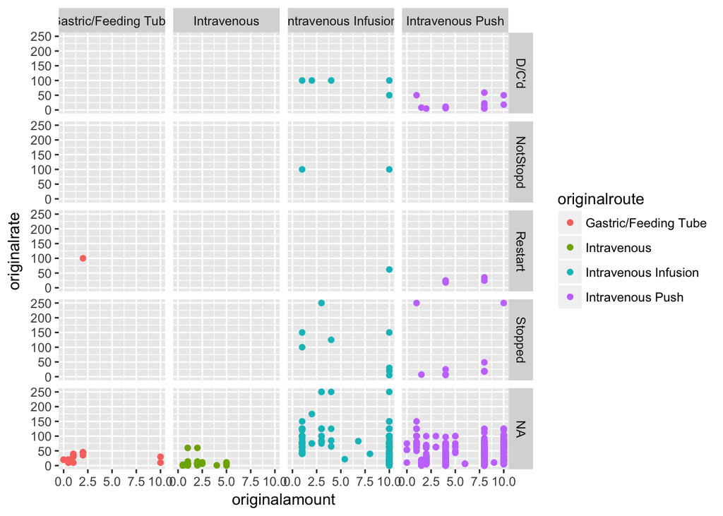

```r
# We can also do a facet grid with two variables
ggplot(data = my_filtered_results) +
  geom_point(mapping = aes(x = originalamount, y = originalrate, color = originalroute)) +
  xlim(0,10) + ylim(0,250) + facet_grid(stopped ~ originalroute)
```

Thus, we find that even within these four groups, the data mostly consists of medication where the infusion status is not known.

We can also smooth the data by using `geom_smooth()` **geom** object. ggplot2 provides over 30 geoms, and extension packages provide even more (see https://www.ggplot2-exts.org for a sampling). The best way to get a comprehensive overview is the ggplot2 cheatsheet, which you can find at http://rstudio.com/cheatsheets. To learn more about any single geom, use help: ?geom_smooth.

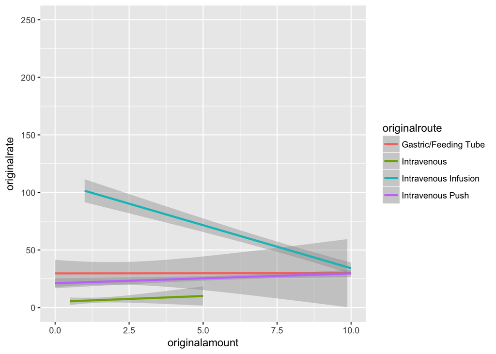

```r
# Smoothing the data using 'geom_smooth()' function
ggplot(data = my_filtered_results, mapping =
         aes(x = originalamount, y = originalrate, color = originalroute)) +
         geom_smooth(method = lm) + xlim(0,10) + ylim(0,250)
```

The smoothing gives an overall picture of the data. We find that as the amount increase the intravenous infusion decreases whereas the gastric/feeding tube or the push remains steady. These types of **directed insights** are the basis for data science.

To get the list of geoms, type the following in the console,

```
> geoms <- help.search("^geom_", package = "ggplot2")`
> geoms$matches[, 1:2]`
```

### Data Transformations

We will study six key `dplyr` library functions that will allow us to solve vast majority of data manipulation challenges:

- Pick observations by their values by `filter()`, which we already saw.
- Reorder the rows applying `arrange()`.
- Pick variables by their names using `select()`.
- Create new variables with functions of existing variables through `mutate()`.
- Collapse many values down to a single summary using `summarise()`.
- And the most important of all which is the `group_by()` operation which can be used with any of the above five.

`arrange()` works similarly to `filter()` except that instead of selecting rows, it changes their order. It takes a data frame and a set of column names (or more complicated expressions) to order by.

```r
# Arranging the filtered data in the descending order of original rate
my_arranged_results <- arrange(my_filtered_results, desc(originalrate))
head(my_arranged_results)
```

```
##       X  row_id subject_id hadm_id icustay_id  charttime itemid amount
## 1 45775 4323092      25428  187711     267387 2160-08-20  30013   12.5
## 2 45776 4323093      25428  187711     267387 2160-08-20  30013   12.5
## 3 45777 4323094      25428  187711     267387 2160-08-20  30013   12.5
## 4 45778 4323095      25428  187711     267387 2160-08-20  30013   12.5
## 5 45779 4323096      25428  187711     267387 2160-08-21  30013   12.5
## 6 45780 4323097      25428  187711     267387 2160-08-21  30013   25.0
##   amountuom rate rateuom  storetime  cgid orderid linkorderid stopped
## 1        ml   NA    <NA> 2160-08-20 15189 9008123     1333734    <NA>
## 2        ml   NA    <NA> 2160-08-20 15189 8253623     1333734    <NA>
## 3        ml   NA    <NA> 2160-08-20 15189 2696590     1333734    <NA>
## 4        ml   NA    <NA> 2160-08-20 15189 4895765     1333734    <NA>
## 5        ml   NA    <NA> 2160-08-21 21570  735250     1333734    <NA>
## 6        ml   NA    <NA> 2160-08-21 21204 9445867     1333734    <NA>
##   newbottle originalamount originalamountuom    originalroute originalrate
## 1        NA            250                ml Intravenous Push         3750
## 2        NA            250                ml Intravenous Push         3750
## 3        NA            250                ml Intravenous Push         3750
## 4        NA            250                ml Intravenous Push         3750
## 5        NA            250                ml Intravenous Push         3750
## 6        NA            250                ml Intravenous Push         3750
##   originalrateuom originalsite
## 1           ml/hr         <NA>
## 2           ml/hr         <NA>
## 3           ml/hr         <NA>
## 4           ml/hr         <NA>
## 5           ml/hr         <NA>
## 6           ml/hr         <NA>
```

Note that we changed the `results` parameter to “show” in the code:

`{r arrangeData, message=FALSE, warning=FALSE, eval=TRUE, dependson="getData",cache=TRUE, results="show"}`

that shows the results (which we want).

We see that this shows all the columns but we may need only a few. This brings us to the next transformation which is `select()`, that can be used to specify only the columns of interest. We may also want to drop the missing values in the selected columns.

```r
# Here we are selecting only the itemid, originalamount, originalrate, originalroute
my_selected_results <- select(my_arranged_results, itemid, originalamount, originalrate, originalroute)
head(my_selected_results)
```

```
##   itemid originalamount originalrate    originalroute
## 1  30013            250         3750 Intravenous Push
## 2  30013            250         3750 Intravenous Push
## 3  30013            250         3750 Intravenous Push
## 4  30013            250         3750 Intravenous Push
## 5  30013            250         3750 Intravenous Push
## 6  30013            250         3750 Intravenous Push
```

By default the ‘NA’ or the missing values are listed in the end which can be viewed by using the function ‘tail’

```r
# View the last few entries of the dataset
tail(my_selected_results)
```

```
##        itemid originalamount originalrate    originalroute
## 114750  30133            600           NA Intravenous Push
## 114751  30043            400           NA Intravenous Push
## 114752  30131            500           NA Intravenous Push
## 114753  30131            500           NA Intravenous Push
## 114754  30025          25000           NA Intravenous Push
## 114755  30338             NA           NA      Intravenous
```

We can remove the missing values using the function `drop_na()`

```r
# Filtering the missing values using 'drop_na()' and view them
my_droppedNA_results <- drop_na(my_selected_results)
tail(my_droppedNA_results)
```

```
##       itemid originalamount originalrate        originalroute
## 49302  30112            600            0     Intravenous Push
## 49303  30123            100            0     Intravenous Push
## 49304  30118           2500            0     Intravenous Push
## 49305  30026             10            0 Intravenous Infusion
## 49306  30124             50            0     Intravenous Push
## 49307  30124             50            0     Intravenous Push
```

Besides selecting sets of existing columns, it’s often useful to add new columns that are functions of existing columns. That’s the job of `mutate()`. For instance, in the selected data above, we may want to see how long the patients were supposed to be given the medication. Since we have the original amount and the original rate, dividing the amount by the rate will give us the time the medication was expected to be admistered. But first we need to remove the entries where is the rate is zero!

```r
# Filtering the rows where the orgininal rate is zero and view them
my_filtered_zero_results <- filter(my_droppedNA_results, originalrate > 0)
tail(my_filtered_zero_results)
```

```
##       itemid originalamount originalrate    originalroute
## 38713  30307             60    0.0363125      Intravenous
## 38714  30307             60    0.0363125      Intravenous
## 38715  30307             60    0.0363125      Intravenous
## 38716  30307             60    0.0363125      Intravenous
## 38717  30118           1000    0.0300000 Intravenous Push
## 38718  30118           1000    0.0300000 Intravenous Push
```

```r
# Creating a new variable 'expectedtime' based on amount and rate
# Note: we round the new variable to two decimal places
my_mutated_results <- mutate(my_filtered_zero_results, expectedtime = round(originalamount/originalrate,2))
head(my_mutated_results)
```

```
##   itemid originalamount originalrate    originalroute expectedtime
## 1  30013            250         3750 Intravenous Push         0.07
## 2  30013            250         3750 Intravenous Push         0.07
## 3  30013            250         3750 Intravenous Push         0.07
## 4  30013            250         3750 Intravenous Push         0.07
## 5  30013            250         3750 Intravenous Push         0.07
## 6  30013            250         3750 Intravenous Push         0.07
```

There are several arithmetic operations and functions one can use with `mutate()`. For a summary, look at the ‘Data Transformation’ chapter in the book, R for Data Science.

```r
# First group the data with the variable 'itemid' and then by 'originalroute'
my_grouped_results <- group_by(my_mutated_results, itemid, originalroute)
# We then find the mean of the values, rounded to 2 decimal places
my_summarized_results <- summarize(my_grouped_results, count = n(),
                                   mean_amount = round(mean(originalamount),2),
                                   mean_rate = round(mean(originalrate),2),
                                   mean_time = round(mean(expectedtime),2))
# View the first few results
head(my_summarized_results)
```

```
## # A tibble: 6 x 6
## # Groups:   itemid [4]
##   itemid        originalroute count mean_amount mean_rate mean_time
##    <int>               <fctr> <int>       <dbl>     <dbl>     <dbl>
## 1  30001     Intravenous Push    36      346.42     98.39      3.51
## 2  30002     Intravenous Push     2      350.00    100.00      3.50
## 3  30005     Intravenous Push    11      299.36     93.18      4.26
## 4  30013          Intravenous    49       50.00      0.62    115.22
## 5  30013 Intravenous Infusion   815     1095.40     76.03     39.36
## 6  30013     Intravenous Push  6440      259.51     20.79     36.38
```

This summary can now be plotted for data exploration.

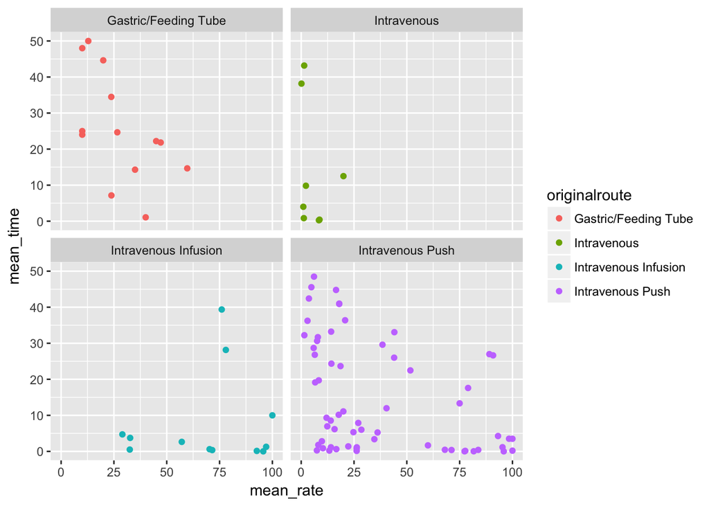

```r
# Plot the summary and use facets
ggplot(data = my_summarized_results) +
  geom_point(mapping = aes(x = mean_rate, y = mean_time, color = originalroute)) +
  xlim(0,100) + ylim(0,50) + facet_wrap(~ originalroute, nrow=2)
```

This plot tells that as the mean rate gets higher the expected time for admistering a drug through intravenous infusion remains low, whereas for the other three routes the expected time gets higher as the rate gets lower.